# Masters Thesis Apendix

Matej Nemec

4/22/2022

# Intro

This document serves as a supplementary material for my thesis demonstrating some of the scripting done to achieve the presented results. It should allow anyone to reproduce the data and evaluate the results for themselves.

# Setup

## Load libraries, set working directory and seed

[output not shown]

Set working directory to the location of this notebook.

```r
try({
  dr = getSrcDirectory()[1]
})
```

```
## Error in getSrcFilename(x, full.names = TRUE, unique = unique) :
##   argument "x" is missing, with no default
```

```r
#when sourcing the file
try({
  dr = dirname(rstudioapi::getActiveDocumentContext()$path)
})
#for running code directly in rstudio
setwd(dr) #set for usage as a script/running lines
knitr::opts_knit$set(root.dir = dr) #set for R markdown chunk execution
```

# Artificial data pipeline

## Load and parse spectra from json

```r
spctr = fromJSON(file = "panel1_lymph_subtracted_fixed.json")
spectra = matrix(ncol = 64, nrow = length(spctr))
rnms = c()
for (i in 1:length(spctr)) {
  spectra[i, ] = spctr[[i]]$spectrum$mS
  rnms = c(rnms, spctr[[i]]$antigen)
}
colnames(spectra) = spctr[[1]]$spectrum$channels
rm(spctr)
rownames(spectra) = rnms
```

## Load and parse phenotype table

Unpack the tree-like structure of the phenotype table using previously defined recursive function.

```r
pheno = read.csv('phenotypes_noAFonly.csv',
                 sep = ',',
                 fileEncoding = "UTF-8-BOM")
todel = c()
pheno = recur_unpack(c('base'), pheno, todel)
#write.csv(pheno,'pheno_unpacked.csv') #if you are interested in unpacked phenotypes uncomment this
```

# Comparison of unmixing methods

## MSE based comparison

1. Compute nougad unmixing

Change **nthreads** parameter appropriately up to the number of threads available to your machine.

```r
stronk = c(2, 3, 9, 14, 17, 21)
res = generate_artificial_cytometry_data(spectra, pheno, 1000, stronk)
received = res[[1]]
gt = res[[2]]
nr = res[[3]]
start.time = Sys.time()
ngd = nougadmt(
  received,
  spectra = spectra,
  snw = 5,
  spw = 1,
  nw = 200,
  start = 2,
  iters = 500,
  alpha = 0.01,
  nthreads = 24
)$unmixed
stop.time = Sys.time()
cat('Multithreaded nougad: ')
```

```
## Multithreaded nougad:
```

```r
stop.time - start.time
```

```
## Time difference of 0.07551599 secs
```

If you want to compare performance with the singlethreaded implementation.

```r
start.time = Sys.time()
ngd = nougad(
  received,
  spectra = spectra,
  snw = 5,
  spw = 1,
  nw = 200,
  start = 2,
  iters = 500,
  alpha = 0.01
)$unmixed
stop.time = Sys.time()
cat('Singlehreaded nougad: ')
```

```
## Singlehreaded nougad:
```

```r
stop.time - start.time
```

```
## Time difference of 0.8622131 secs
```

2. Compute OLS unmixing

```r
ols = t(lm(t(received) ~ t(spectra) + 0)$coefficients)
```

2. Compute weighted OLS

```r
wols = ols
for (i in 1:nr) {
  ws = norm(pmax(0, received[i, ] / sum(received[i, ])))
  wols[i, ] = t(lm(t(received[i, , drop = F]) ~ t(spectra) + 0, weights =
                     ws)$coefficients)
}
```

4. Compute MSE against ground truth

```r
ngd_t = trans(ngd)
ols_t = trans(ols)
wols_t = trans(wols)
gt_t = trans(gt)
ngd_diff = mse(gt_t, ngd_t)
wols_diff = mse(gt_t, wols_t)
ols_diff = mse(gt_t, ols_t)
cat(paste0('MSE for NGD: ', ngd_diff , '\n'))
```

```
## MSE for NGD: 0.761716360529201
```

```r
cat(paste0('MSE for WOLS: ', wols_diff , '\n'))
```

```
## MSE for WOLS: 1.87596849689024
```

```r
cat(paste0('MSE for OLS: ', ols_diff , '\n'))
```

```
## MSE for OLS: 1.23915385153287
```

## Compare error distributions

1. Compare error distribution shape and magnitude over different methods.

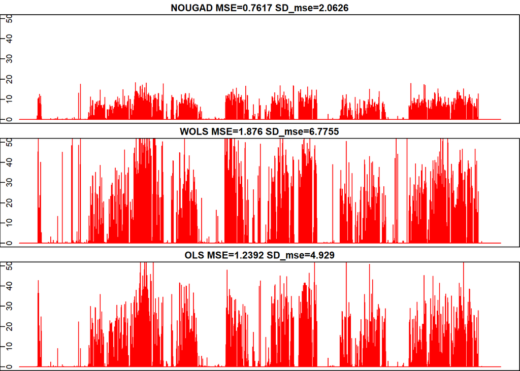

```r
ngd_err = (trans(ngd) - trans(gt)) ^ 2
ols_err = (trans(ols) - trans(gt)) ^ 2
wols_err = (trans(wols) - trans(gt)) ^ 2
x = 1:length(ngd_err)
par(
  mfrow = c(3, 1),
  tcl = 0.5,
  mgp = c(0,-1.4, 0),
  mar = c(0, 0, 1.5, 0)
)
plot(
  x,
  ngd_err,
  type = 'l',
  col = 'red',
  pch = 16,
  cex = .1,
  ylim = c(0, 50),
  main = paste0('NOUGAD MSE=', round(ngd_diff, 4), ' SD_mse=', round(sd(ngd_err), 4)),
  xaxt = 'n'
)
plot(
  x,
  wols_err,
  type = 'l',
  col = 'red',
  pch = 16,
  cex = .1,
  ylim = c(0, 50),
  main = paste0('WOLS MSE=', round(wols_diff, 4), ' SD_mse=', round(sd(wols_err), 4)),
  xaxt = 'n'
)
plot(
  x,
  ols_err,
  type = 'l',
  col = 'red',
  pch = 16,
  cex = .1,
  ylim = c(0, 50),
  main = paste0('OLS MSE=', round(ols_diff, 4), ' SD_mse=', round(sd(ols_err), 4)),
  xaxt = 'n'
)
```

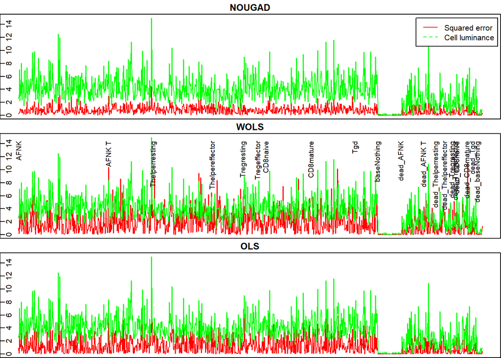

```r
total_brightness = rowSums(received)
ngd_mcr = rowSums(ngd_err) / ncol(ngd_err)
ols_mcr = rowSums(ols_err) / ncol(ols_err)
wols_mcr = rowSums(wols_err) / ncol(wols_err)
rnms = rownames(received)
rnms = sapply(strsplit(rnms, split = '.', fixed = TRUE), function(x)
  (x[1]))
uq = unique(rnms)
occurs = Vectorize(grep, 'pattern')(paste0('^', uq, '$'), rnms)
cnts = as.vector(sapply(occurs, length))
coords = c(0)
for (i in 1:length(cnts))
{
  coords[i + 1] = sum(cnts[1:i])
}
coords = coords[-length(coords)]
end_point = 0.5 + length(uq) + length(uq) - 1 #this is the line which does the trick (together with barplot "space = 1" parameter)

x = 1:(nrow(received))
par(
  mfrow = c(3, 1),
  tcl = 0.5,
  mgp = c(0,-1.4, 0),
  mar = c(0, 0, 1.5, 0)
)
plot(
  x,
  ngd_mcr,
  pch = 16,
  cex = .1,
  ylim = c(0, 15),
  main = 'NOUGAD',
  type = 'l',
  col = 'red',
  xaxt = 'n',
  yaxt = 'n'
)
lines(x, norm(total_brightness) * 15 , col = "green")
legend(
  round(length(x) - 1 / 7 * length(x)),
  15,
  legend = c("Squared error", "Cell luminance"),
  col = c("red", "green"),
  lty = 1:2
)
axis(2,
     at = seq(0, 15, 2),
     labels = T,
     gap.axis = 0)
plot(
  x,
  wols_mcr,
  pch = 16,
  cex = .1,
  ylim = c(0, 15),
  main = 'WOLS',
  type = 'l',
  col = 'red',
  xaxt = 'n',
  xlab = '',
  yaxt = 'n'
)
lines(x, norm(total_brightness) * 15 , col = "green")
text(
  coords,
  par("usr")[3] + 15,
  srt = 90,
  adj = 1,
  xpd = TRUE,
  labels = uq,
  cex = 0.9
)
axis(1,
     gap.axis = 1,
     padj = 0.5,
     xaxt = 'n')
axis(2,
     at = seq(0, 15, 2),
     labels = T,
     gap.axis = 0)
plot(
  x,
  ols_mcr,
  pch = 16,
  cex = .1,
  ylim = c(0, 15),
  main = 'OLS',
  type = 'l',
  col = 'red',
  xaxt = 'n',
  yaxt = 'n'
)
lines(x, norm(total_brightness) * 15 , col = "green")
axis(2,
     at = seq(0, 15, 2),
     labels = T,
     gap.axis = 0)
```

Correlation of mean per cell error with total cell brightness:

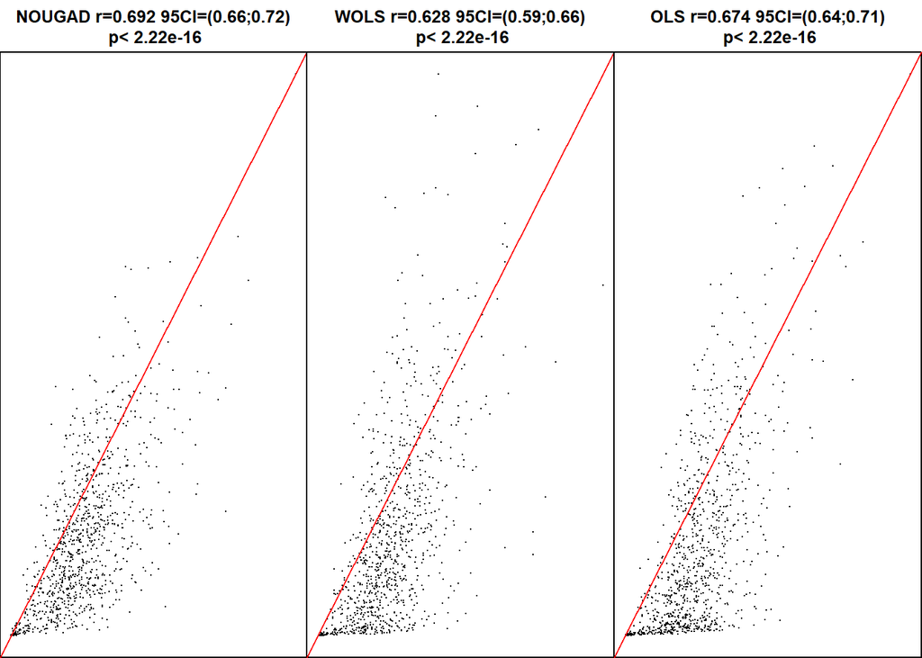

```r
df_ngd = data.frame(
  cell_brightness = norm(total_brightness),
  mean_cell_error = norm(ngd_mcr)
)
df_ngd = df_ngd[order(df_ngd$mean_cell_error), ]
df_ols = data.frame(
  cell_brightness = norm(total_brightness),
  mean_cell_error = norm(ols_mcr)
)
df_ols = df_ols[order(df_ols$mean_cell_error), ]
df_wols = data.frame(
  cell_brightness = norm(total_brightness),
  mean_cell_error = norm(wols_mcr)
)
df_wols = df_wols[order(df_wols$mean_cell_error), ]

cn = cor.test(df_ngd$cell_brightness, df_ngd$mean_cell_error)
co = cor.test(df_ols$cell_brightness, df_ols$mean_cell_error)
cw = cor.test(df_wols$cell_brightness, df_wols$mean_cell_error)

par(mar = c(0, 0, 3, 0), mfrow = c(1, 3))
plot(
  df_ngd$cell_brightness,
  df_ngd$mean_cell_error,
  pch = 16,
  cex = .1,
  main = paste0(
    'NOUGAD r=',
    round(cn$estimate, 3),
    ' 95CI=(',
    round(cn$conf.int[1], 2),
    ';',
    round(cn$conf.int[2], 2),
    ')\n p',
    format.pval(cn$p.value)
  ),
  xaxt = 'n',
  yaxt = 'n'
)
abline(0, 1, col = 'red')
plot(
  df_wols$cell_brightness,
  df_wols$mean_cell_error,
  pch = 16,
  cex = .1,
  main = paste0(
    'WOLS r=',
    round(cw$estimate, 3),
    ' 95CI=(',
    round(cw$conf.int[1], 2),
    ';',
    round(cw$conf.int[2], 2),
    ')\n p',
    format.pval(cw$p.value)
  ),
  xaxt = 'n',
  yaxt = 'n'
)
abline(0, 1, col = 'red')
plot(
  df_ols$cell_brightness,
  df_ols$mean_cell_error,
  pch = 16,
  cex = .1,
  main = paste0(
    'OLS r=',
    round(co$estimate, 3),
    ' 95CI=(',
    round(co$conf.int[1], 2),
    ';',
    round(co$conf.int[2], 2),
    ')\n p',
    format.pval(co$p.value)
  ),
  xaxt = 'n',
  yaxt = 'n'
)
abline(0, 1, col = 'red')
```

3. Compare error distribution over different spectra for different methods This should serve to look at which spectra are more prone to errors and how/if the error distribution for each spectrum changes depending on the selected method. Note that counts (Y axis) are log scaled.

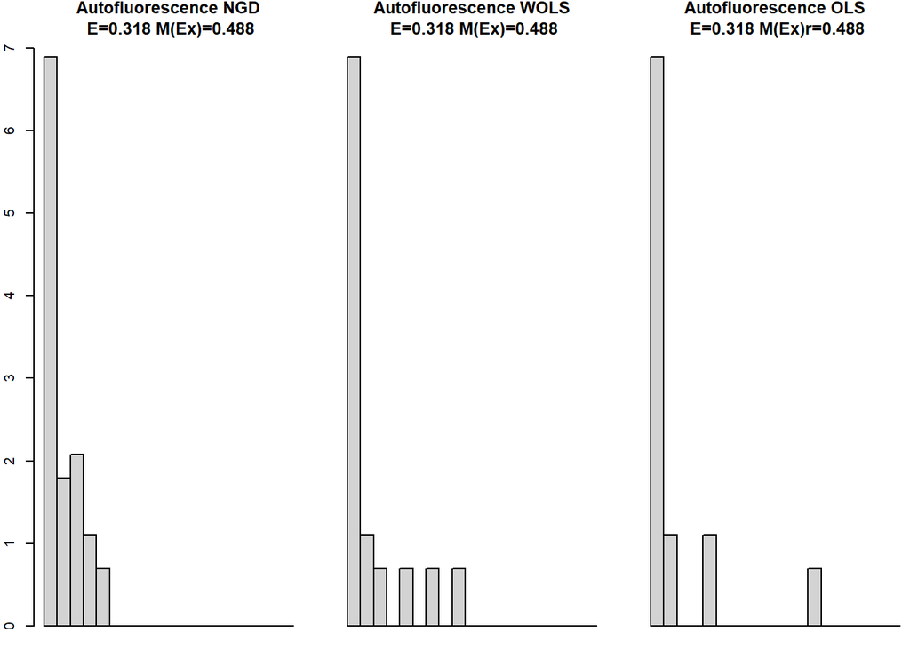

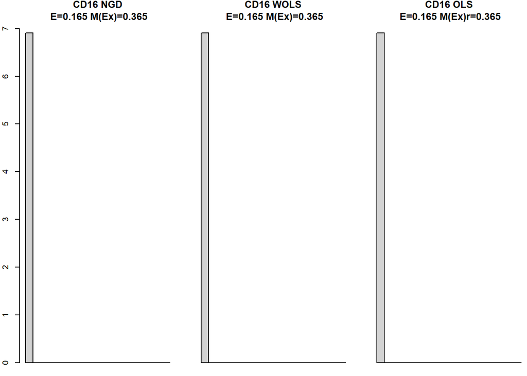

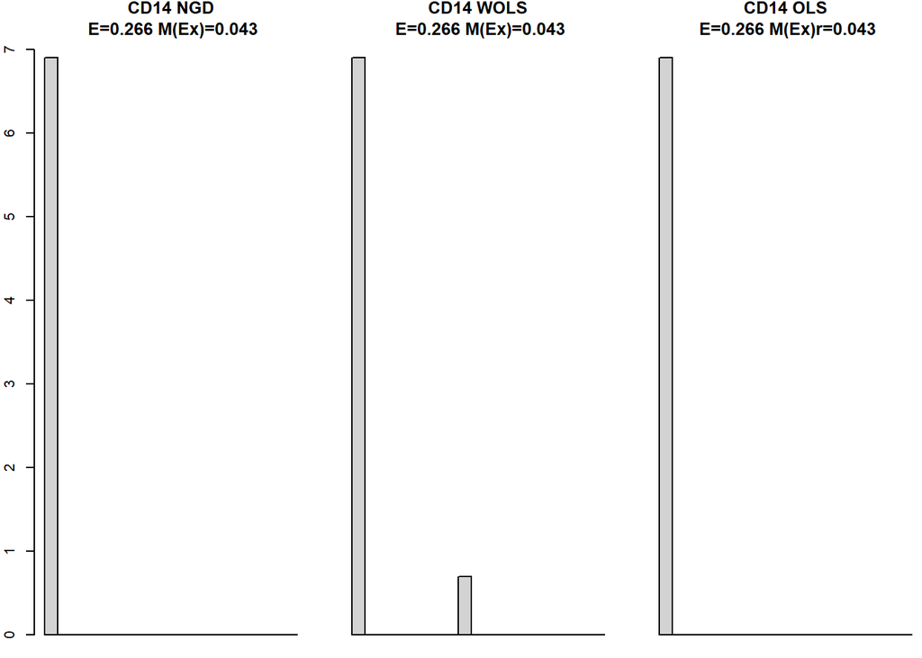

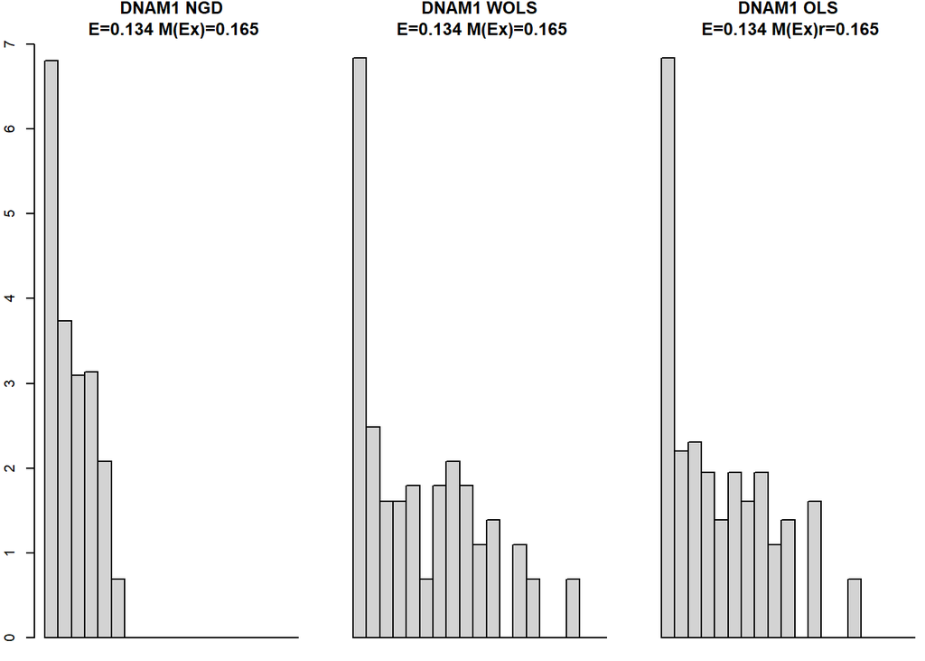

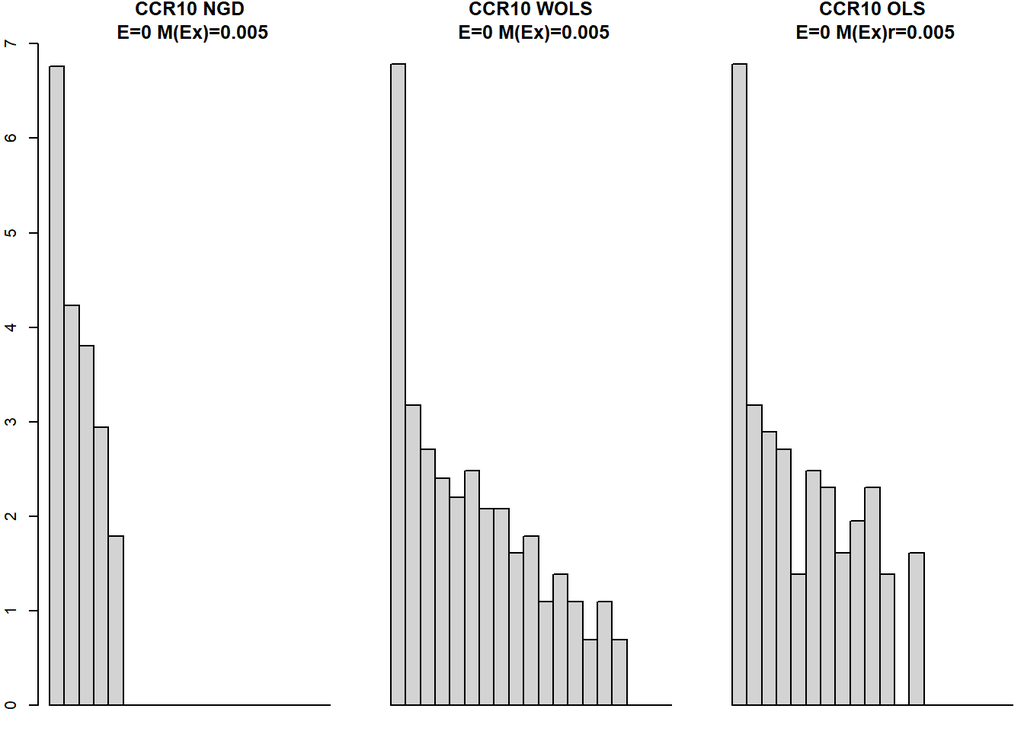

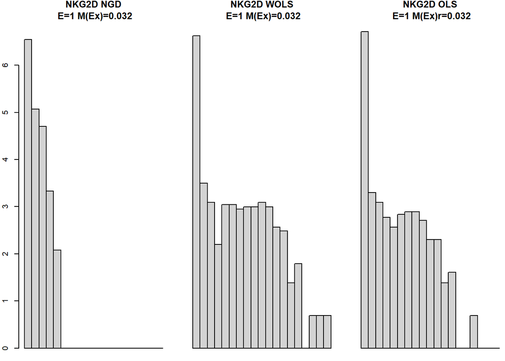

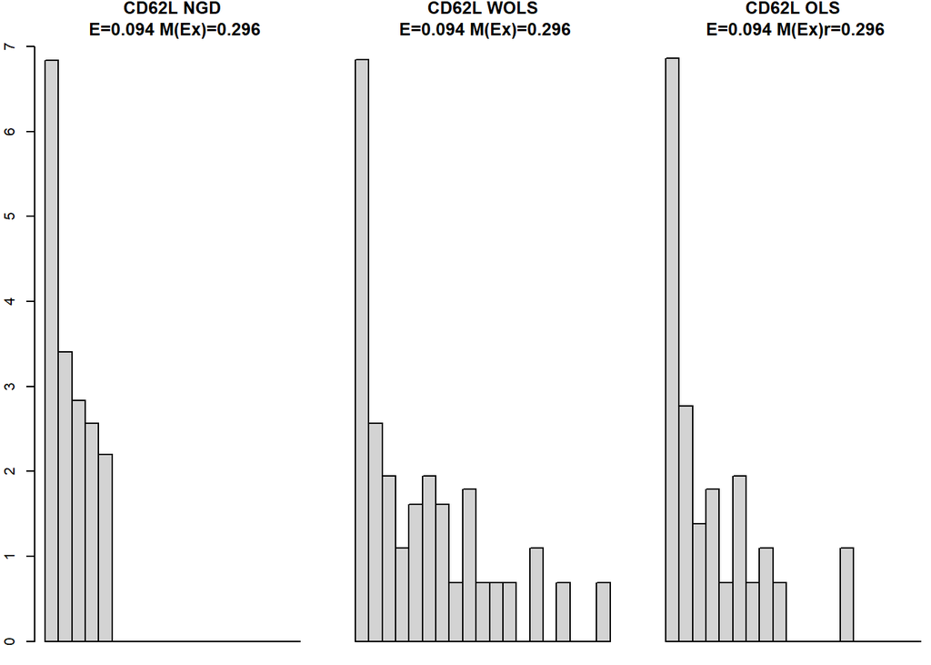

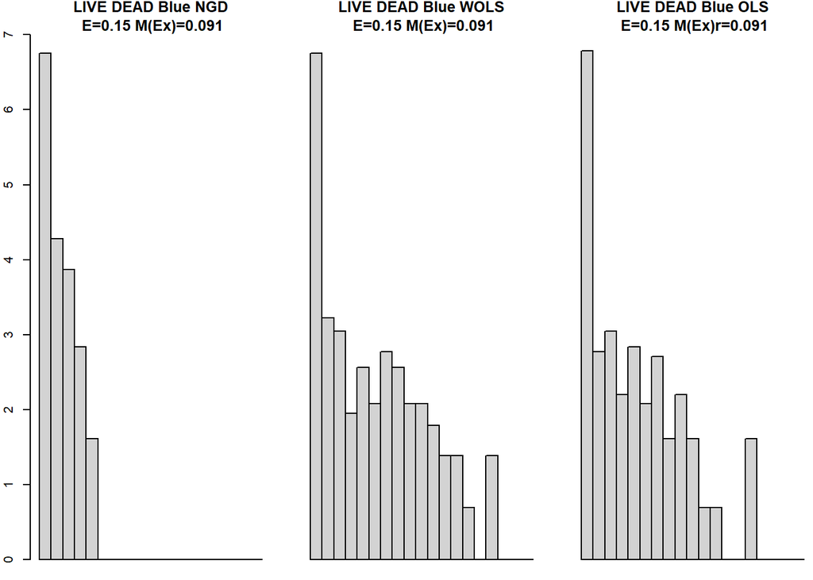

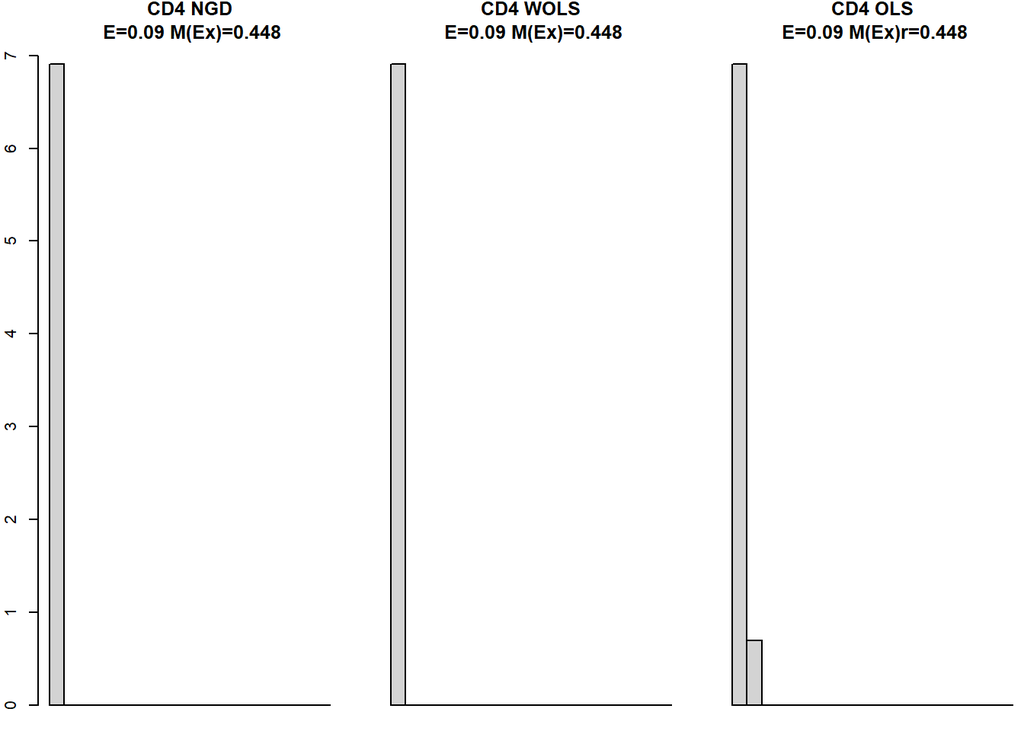

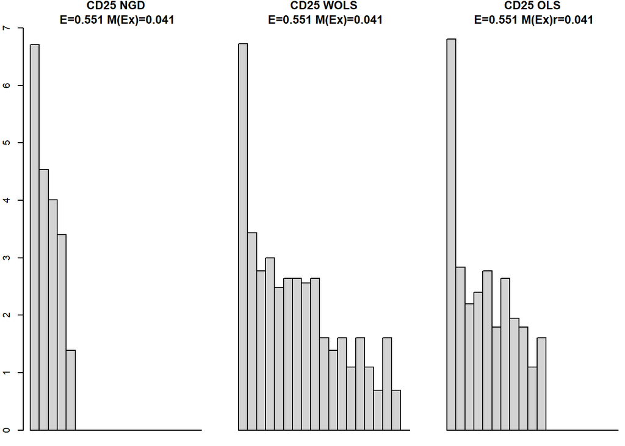

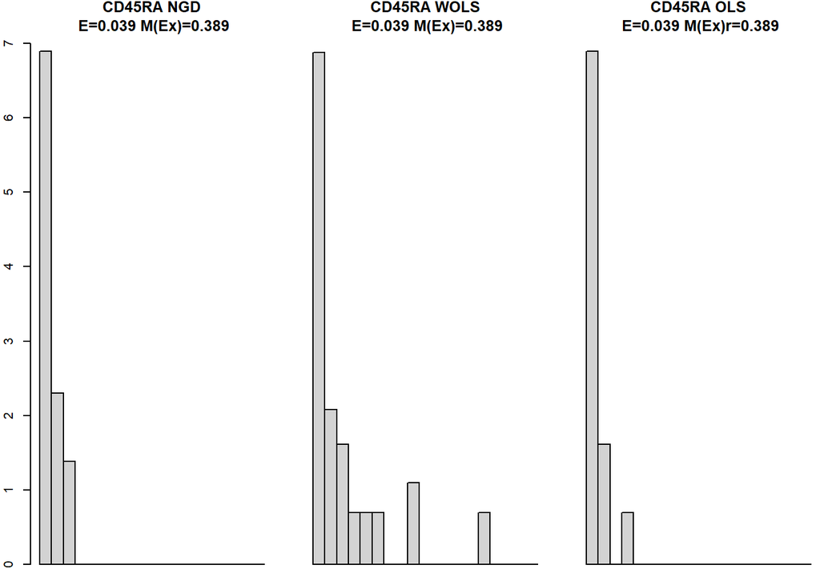

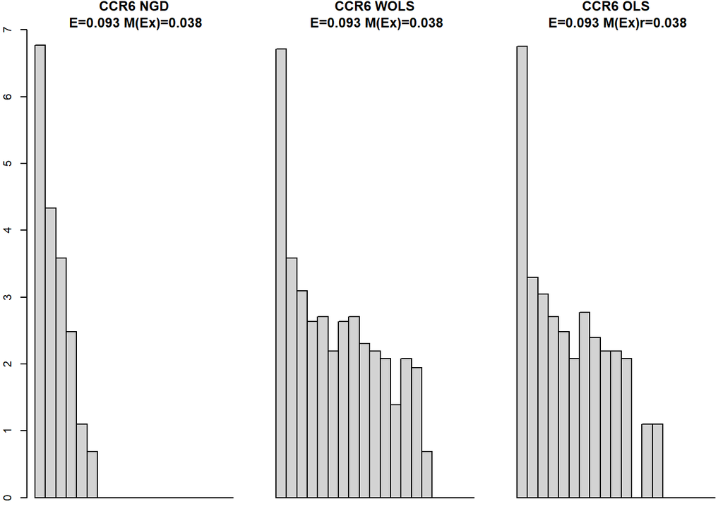

[9 more figures not shown]

```r
spec_int = norm(rowSums(spectra) ^ 2) #Total energy of the given spectrum
mean_ag_expr = norm(colSums(gt) / ncol(gt))#Mean expression of that spectrum in the data (ground truth)

for (i in 1:nrow(spectra)) {
  par(mar = c(0, 2, 2, 0), mfrow = c(1, 3))
  ols_vec = ols_err[, i]
  wols_vec = wols_err[, i]
  ngd_vec = ngd_err[, i]
  xmx = max(c(max(ols_vec), max(wols_vec), max(ngd_vec)))
  h_ols =
    hist(ols_vec,
         plot = FALSE,
         breaks = seq(0, xmx, length.out = 20))
  h_ols$counts = log(h_ols$counts)
  h_ols$counts[h_ols$counts == -Inf] = 0
  h_wols =
    hist(wols_vec,
         plot = FALSE,
         breaks = seq(0, xmx, length.out = 20))
  h_wols$counts = log(h_wols$counts)
  h_wols$counts[h_wols$counts == -Inf] = 0
  h_ngd =
    hist(ngd_vec,
         plot = FALSE,
         breaks = seq(0, xmx, length.out = 20))
  h_ngd$counts = log(h_ngd$counts)
  h_ngd$counts[h_ngd$counts == -Inf] = 0
  ymx = max(c(max(h_ols$counts), max(h_wols$counts), max(h_ngd$counts)))
  plot(
    h_ngd,
    main = paste0(
      rownames(spectra)[i],
      ' NGD\n E=',
      round(spec_int[i], 3),
      ' M(Ex)=',
      round(mean_ag_expr[i], 3)
    ),
    xaxt = 'n',
    xlim = c(0, xmx),
    ylim = c(0, ymx)
  )
  plot(
    h_wols,
    main = paste0(
      rownames(spectra)[i],
      ' WOLS\n E=',
      round(spec_int[i], 3),
      ' M(Ex)=',
      round(mean_ag_expr[i], 3)
    ),
    xaxt = 'n',
    xlim = c(0, xmx),
    ylim = c(0, ymx),
    yaxt = 'n'
  )
  plot(
    h_ols,
    main = paste0(
      rownames(spectra)[i],
      ' OLS\n E=',
      round(spec_int[i], 3),
      ' M(Ex)r=',
      round(mean_ag_expr[i], 3)
    ),
    xaxt = 'n',
    xlim = c(0, xmx),
    ylim = c(0, ymx),
    yaxt = 'n'
  )

}
```

Correlation of mean spectrum error with the spectrum energy.

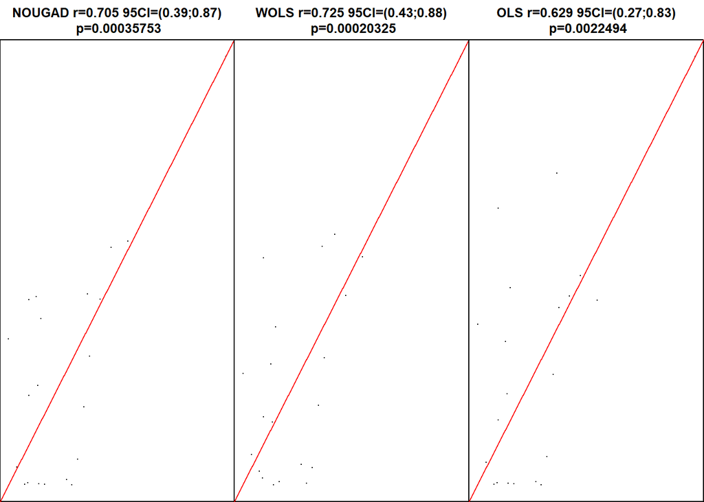

```r
ngd_msr = colSums(ngd_err) / nrow(ngd_err)
ols_msr = colSums(ols_err) / nrow(ols_err)
wols_msr = colSums(wols_err) / nrow(wols_err)

df_ngd = data.frame(spectrum_energy = norm(spec_int),
                    mean_spectrum_error = norm(ngd_msr))
df_ngd = df_ngd[order(df_ngd$mean_spectrum_error), ]
df_ols = data.frame(spectrum_energy = norm(spec_int),
                    mean_spectrum_error = norm(ols_msr))
df_ols = df_ols[order(df_ols$mean_spectrum_error), ]
df_wols = data.frame(spectrum_energy = norm(spec_int),
                     mean_spectrum_error = norm(wols_msr))
df_wols = df_wols[order(df_wols$mean_spectrum_error), ]

cn = cor.test(ngd_msr, spec_int)
co = cor.test(ols_msr, spec_int)
cw = cor.test(wols_msr, spec_int)

par(mar = c(0, 0, 3, 0), mfrow = c(1, 3))
plot(
  df_ngd$spectrum_energy,
  df_ngd$mean_spectrum_error,
  pch = 16,
  cex = .1,
  main = paste0(
    'NOUGAD r=',
    round(cn$estimate, 3),
    ' 95CI=(',
    round(cn$conf.int[1], 2),
    ';',
    round(cn$conf.int[2], 2),
    ')\n p=',
    format.pval(cn$p.value)
  ),
  xaxt = 'n',
  yaxt = 'n'
)
abline(0, 1, col = 'red')
plot(
  df_wols$spectrum_energy,
  df_wols$mean_spectrum_error,
  pch = 16,
  cex = .1,
  main = paste0(
    'WOLS r=',
    round(cw$estimate, 3),
    ' 95CI=(',
    round(cw$conf.int[1], 2),
    ';',
    round(cw$conf.int[2], 2),
    ')\n p=',
    format.pval(cw$p.value)
  ),
  xaxt = 'n',
  yaxt = 'n'
)
abline(0, 1, col = 'red')
plot(
  df_ols$spectrum_energy,
  df_ols$mean_spectrum_error,
  pch = 16,
  cex = .1,
  main = paste0(
    'OLS r=',
    round(co$estimate, 3),
    ' 95CI=(',
    round(co$conf.int[1], 2),
    ';',
    round(co$conf.int[2], 2),
    ')\n p=',
    format.pval(co$p.value)
  ),
  xaxt = 'n',
  yaxt = 'n'
)
abline(0, 1, col = 'red')
```

## Visually compare unmixed cells to ground truth in 2D space

1. Compare selected marker pairs on 2D plots

Using lines.

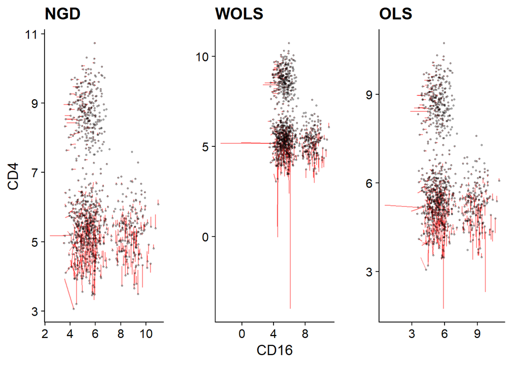

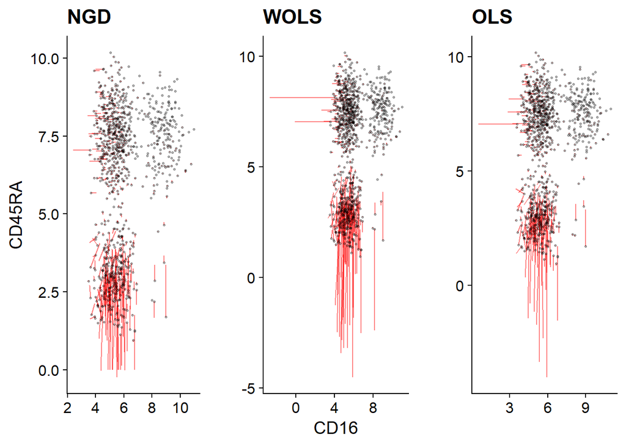

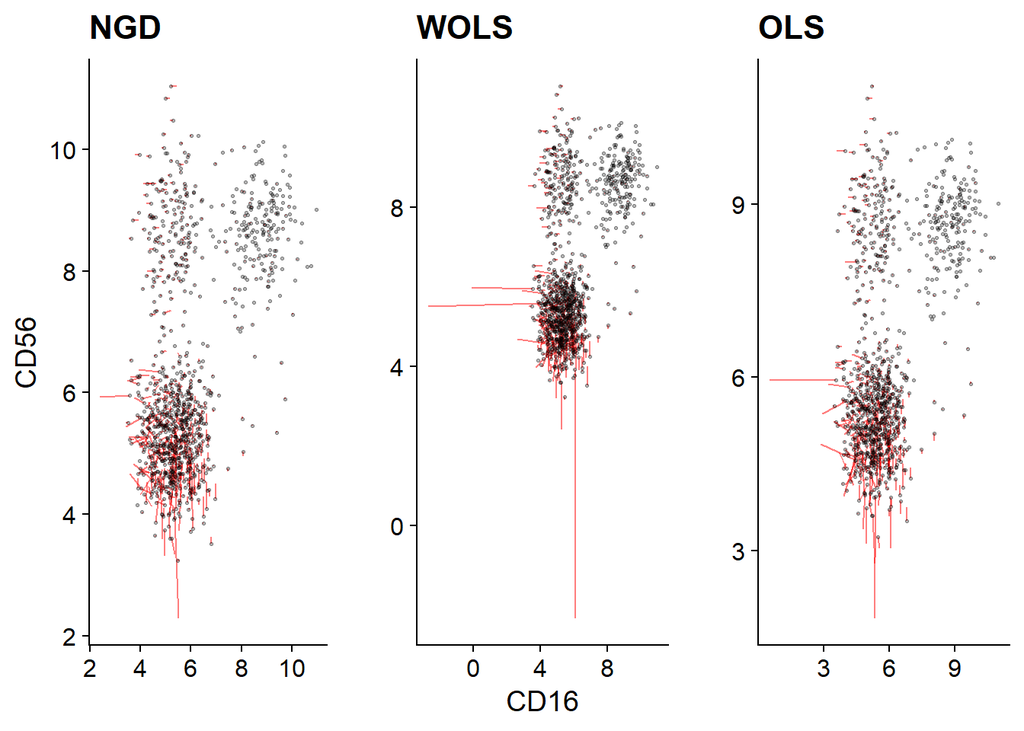

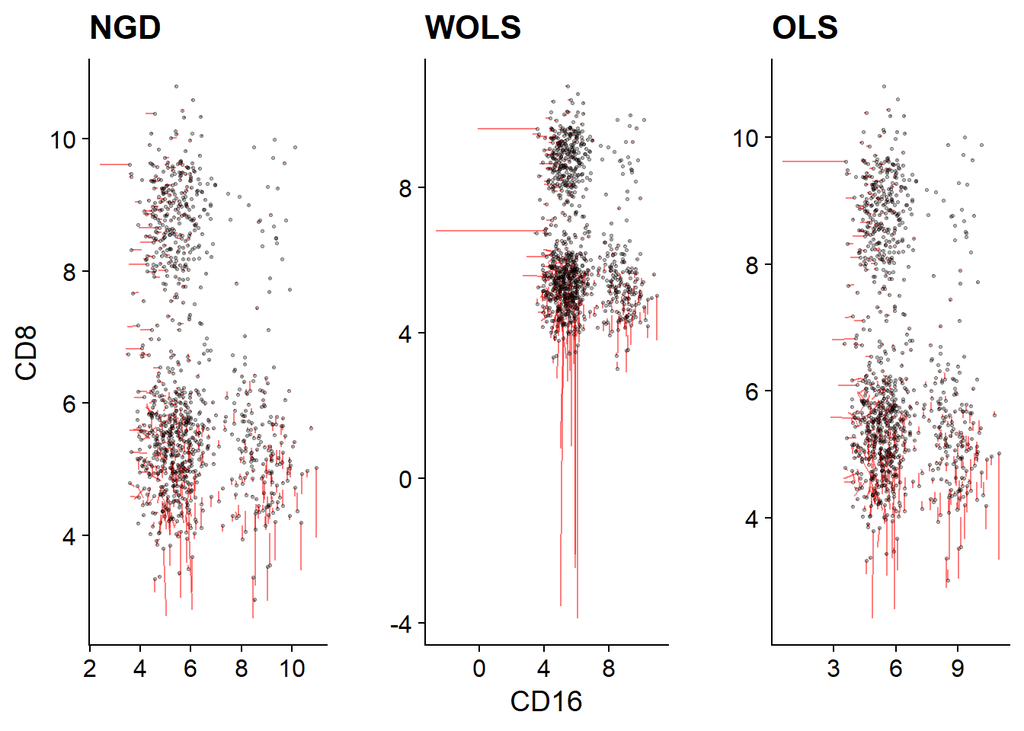

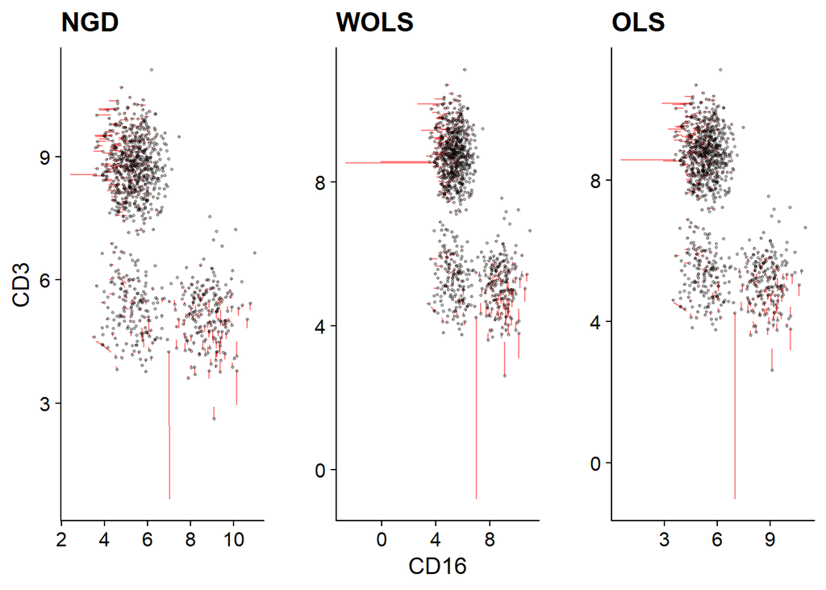

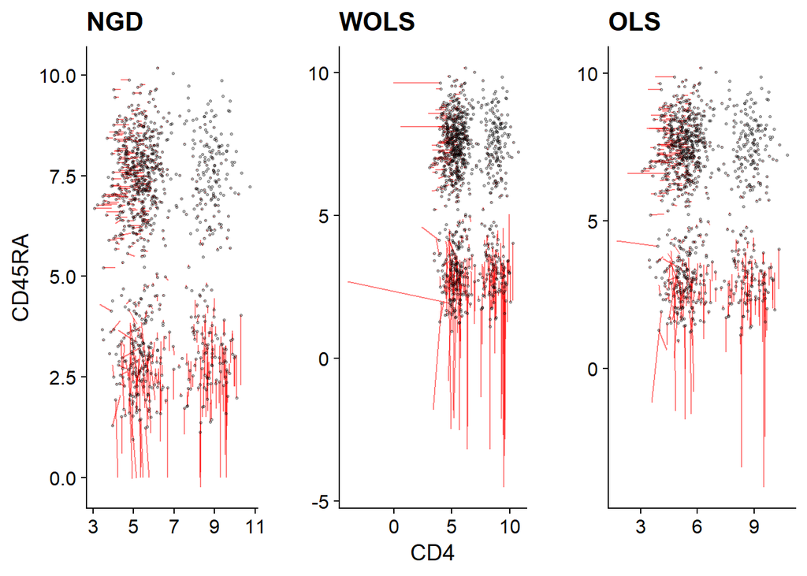

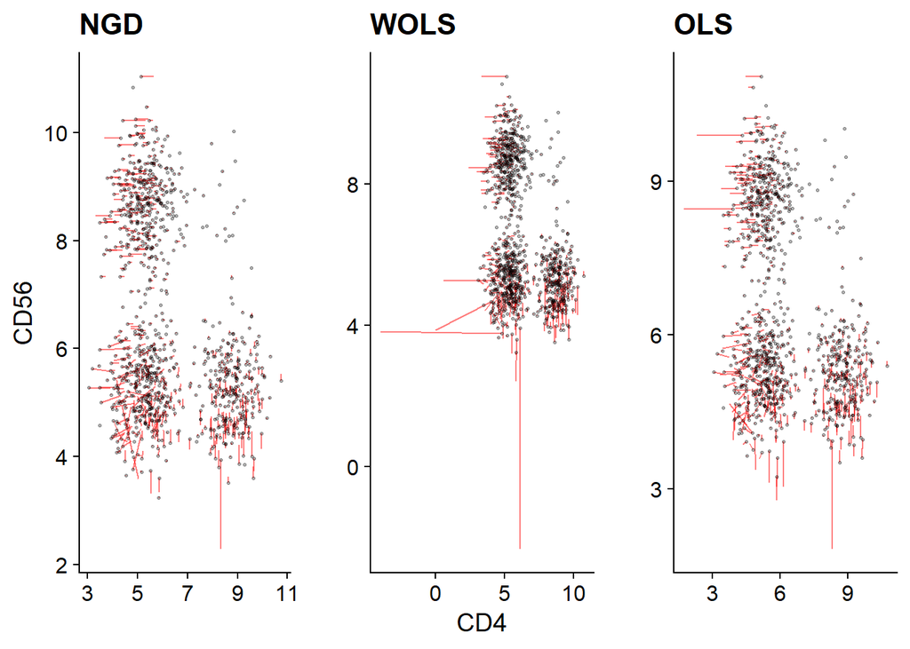

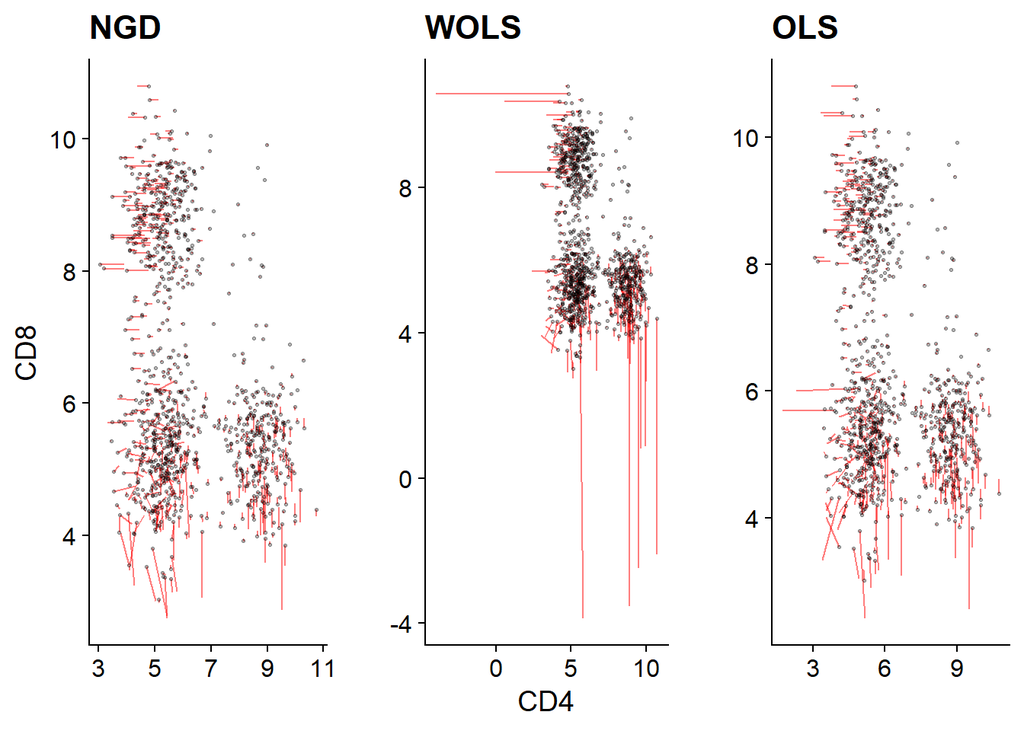

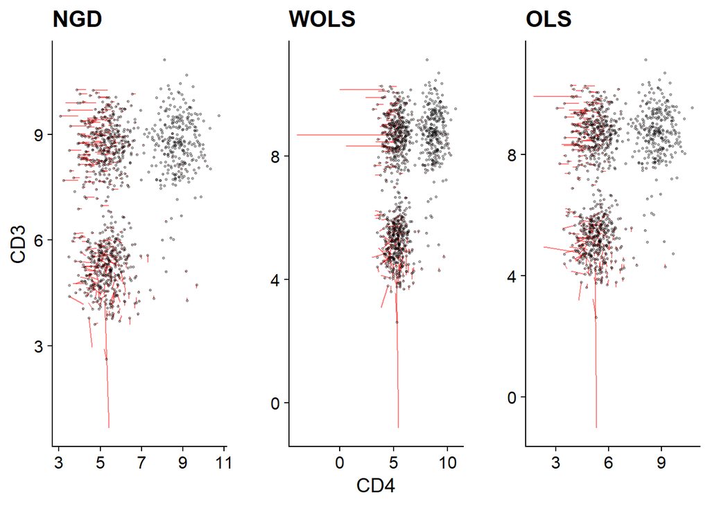

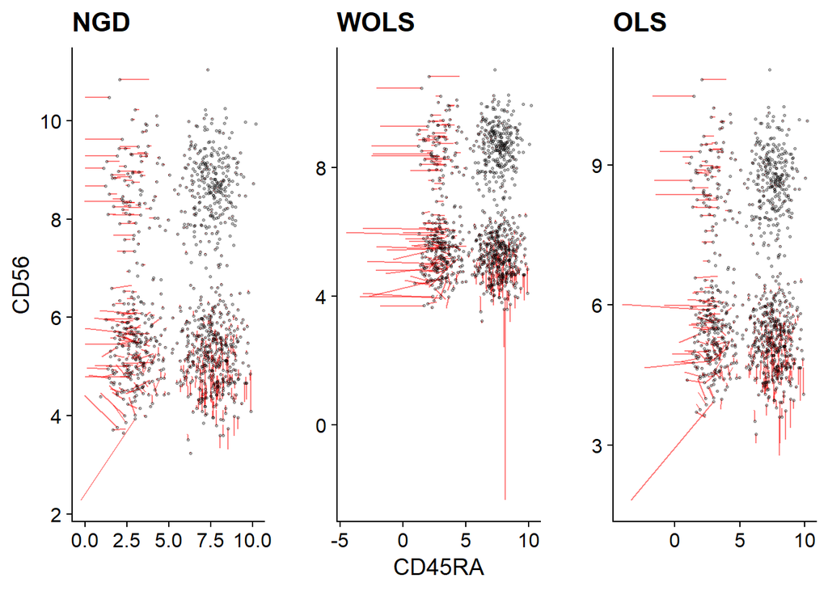

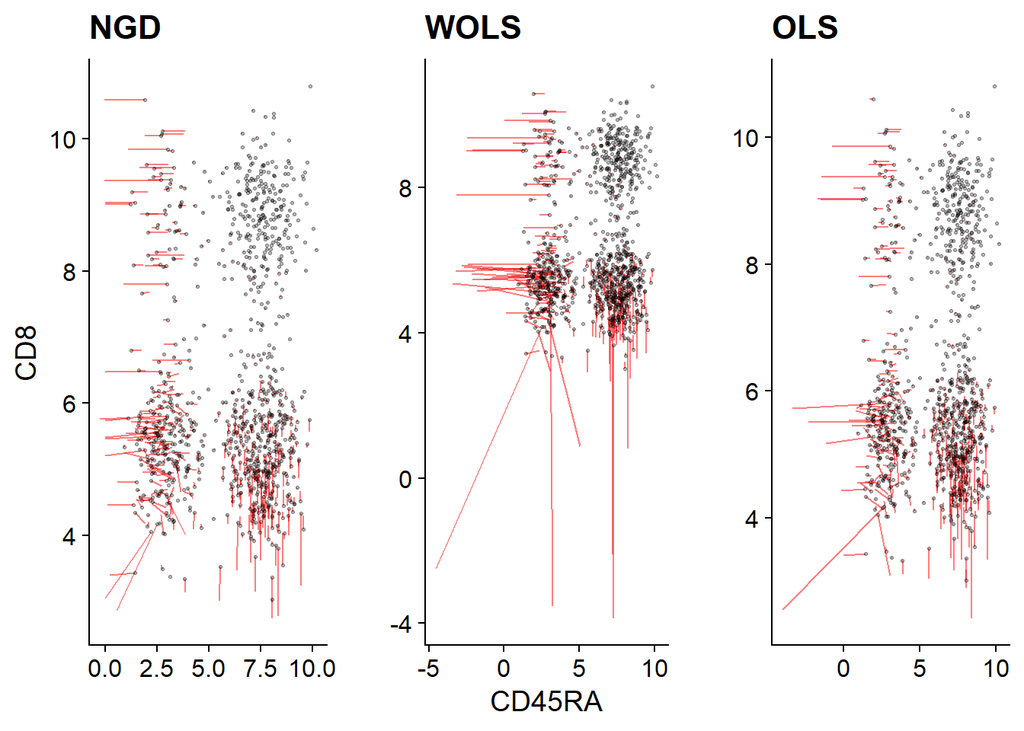

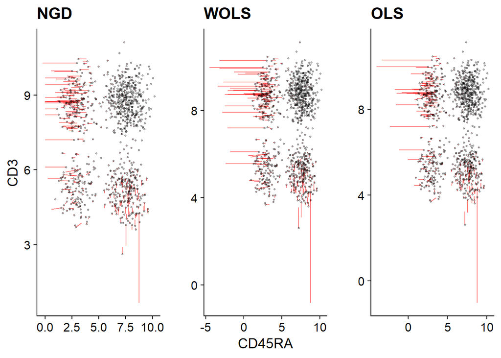

[3 more figures not shown]

```r
colnames(gt_t) = rownames(spectra)
colnames(ngd_t) = rownames(spectra)
colnames(ols_t) = rownames(spectra)
colnames(wols_t) = rownames(spectra)

ngd_t = as.data.frame(ngd_t)
gt_t = as.data.frame(gt_t)
ols_t = as.data.frame(ols_t)
wols_t = as.data.frame(wols_t)

marker_cords = which(mean_ag_expr > 0.3)
markers = rownames(spectra)[marker_cords]
markers = markers[markers != 'Autofluorescence']
combos = combn(markers, 2)
for (i in 1:ncol(combos)) {
  df_ngd = data.frame(
    X1 = gt_t[combos[1, i]][, 1],
    X2 = gt_t[combos[2, i]][, 1],
    X1.1 = ngd_t[combos[1, i]][, 1],
    X2.1 = ngd_t[combos[2, i]][, 1]
  )
  df_ols = data.frame(
    X1 = gt_t[combos[1, i]][, 1],
    X2 = gt_t[combos[2, i]][, 1],
    X1.1 = ols_t[combos[1, i]][, 1],
    X2.1 = ols_t[combos[2, i]][, 1]
  )
  df_wols = data.frame(
    X1 = gt_t[combos[1, i]][, 1],
    X2 = gt_t[combos[2, i]][, 1],
    X1.1 = wols_t[combos[1, i]][, 1],
    X2.1 = wols_t[combos[2, i]][, 1]
  )

  p1 = ggplot()  + geom_segment(
    data = df_ngd,
    aes(
      x = X1,
      y = X2,
      xend = X1.1,
      yend = X2.1
    ),
    colour = "red",
    alpha = 0.5
  ) + geom_point(aes(x = df_ngd$X1, y = df_ngd$X2),
                 size = 0.5,
                 alpha = 0.3) + theme_cowplot() + ylab(combos[2, i]) + xlab('') + ggtitle('NGD')
  p2 = ggplot()  + geom_segment(
    data = df_wols,
    aes(
      x = X1,
      y = X2,
      xend = X1.1,
      yend = X2.1
    ),
    colour = "red",
    alpha = 0.5
  ) + geom_point(aes(x = df_ngd$X1, y = df_ngd$X2),
                 size = 0.5,
                 alpha = 0.3) + theme_cowplot() + ylab('') + xlab(combos[1, i]) + ggtitle('WOLS')
  p3 = ggplot()  + geom_segment(
    data = df_ols,
    aes(
      x = X1,
      y = X2,
      xend = X1.1,
      yend = X2.1
    ),
    colour = "red",
    alpha = 0.5
  ) + geom_point(aes(x = df_ngd$X1, y = df_ngd$X2),
                 size = 0.5,
                 alpha = 0.3) + theme_cowplot() + ylab('') + xlab('') + ggtitle('OLS')

  print(ggarrange(p1, p2, p3, ncol = 3))

}
```

Color cells by squared error magnitude.